# Diabetes Prediction Case Study

## About Dataset

This dataset is originally from the National Institute of Diabetes and Digestive and Kidney Diseases. The objective of the dataset is to diagnostically predict whether a patient has diabetes, based on certain diagnostic measurements included in the dataset. Several constraints were placed on the selection of these instances from a larger database. In particular, all patients here are females at least 21 years old of Pima Indian heritage.2 From the data set in the (.csv) File We can find several variables, some of them are independent (several medical predictor variables) and only one target dependent variable (Outcome).

```r
library(tidyverse)
library(tidymodels)
library(repr)
library(broom)
library(leaps)
library(readr)
library(GGally)
library(pheatmap)
```

```
• Learn how to get started at https://www.tidymodels.org/start/
```

## Data

- `Pregnancies`: Number of pregnancies
- `Glucose`: Glucose Level in Blood (in mg/dL)
- `BloodPressue`: Blood Pressure measurement (in mm Hg)
- `SkinThickness`: Thickness of skin (in mm)
- `Insulin`: Insulin Level in Blood
- `BMI`: Body Mass Index
- `DiabetesPedigreeFunction`: Likelihood of developing diabetes based on family history as percentage
- `Age`: Age of patient (in Years)
- `Outcome`: To express the final result 1 is Yes and 0 is No

## Question of Interest

Using this dataset, we aim to answer the question: What is the likelihood of a patient having diabetes based on key diagnostic factors?

The response variable for our analysis is the diabetes outcome (a binary variable indicating whether a patient has diabetes). The explanatory variables include medical predictors such as glucose levels, blood pressure, body mass index (BMI), age, insulin levels, and the diabetes pedigree function.

### Focus: Prediction and Inference

- *Predict* the probability that a new patient has diabetes, based on the explanatory variables.
- *Infer* which variables are the most significant predictors of diabetes, providing insights into how specific health factors relate to diabetes risk.

```r
path <- "./diabetes.csv"
diabetes <- read_csv(path) |>
    filter(SkinThickness != 0, Insulin != 0)
head(diabetes)
tail(diabetes)
```

A tibble: 6 × 9

| Pregnancies <dbl> | Glucose <dbl> | BloodPressure <dbl> | SkinThickness <dbl> | Insulin <dbl> | BMI <dbl> | DiabetesPedigreeFunction <dbl> | Age <dbl> | Outcome <dbl> |
| --- | --- | --- | --- | --- | --- | --- | --- | --- |
| 1 | 89 | 66 | 23 | 94 | 28.1 | 0.167 | 21 | 0 |
| 0 | 137 | 40 | 35 | 168 | 43.1 | 2.288 | 33 | 1 |
| 3 | 78 | 50 | 32 | 88 | 31.0 | 0.248 | 26 | 1 |
| 2 | 197 | 70 | 45 | 543 | 30.5 | 0.158 | 53 | 1 |
| 1 | 189 | 60 | 23 | 846 | 30.1 | 0.398 | 59 | 1 |
| 5 | 166 | 72 | 19 | 175 | 25.8 | 0.587 | 51 | 1 |

A tibble: 6 × 9

| Pregnancies <dbl> | Glucose <dbl> | BloodPressure <dbl> | SkinThickness <dbl> | Insulin <dbl> | BMI <dbl> | DiabetesPedigreeFunction <dbl> | Age <dbl> | Outcome <dbl> |
| --- | --- | --- | --- | --- | --- | --- | --- | --- |
| 1 | 121 | 78 | 39 | 74 | 39.0 | 0.261 | 28 | 0 |
| 0 | 181 | 88 | 44 | 510 | 43.3 | 0.222 | 26 | 1 |
| 1 | 128 | 88 | 39 | 110 | 36.5 | 1.057 | 37 | 1 |
| 2 | 88 | 58 | 26 | 16 | 28.4 | 0.766 | 22 | 0 |
| 10 | 101 | 76 | 48 | 180 | 32.9 | 0.171 | 63 | 0 |
| 5 | 121 | 72 | 23 | 112 | 26.2 | 0.245 | 30 | 0 |

## Exploratory Data Analysis

```r
outcome_counts = diabetes |>
    count(Outcome)
outcome_counts
```

A spec_tbl_df: 2 × 2

| Outcome <dbl> | n <int> |
| --- | --- |
| 0 | 264 |
| 1 | 130 |

After counting the number of patients in our dataset who had a postive and negative diagnosis of diabetes, we notice that there are more patients without diabetes.

## Pair Plots

```r
diabetes_data_pairplots <- diabetes |>
    ggpairs(progress = FALSE) +
    theme(
        text = element_text(size = 15),
        plot.title = element_text(face = "bold"),
        axis.title = element_text(face = "bold")
    )
```

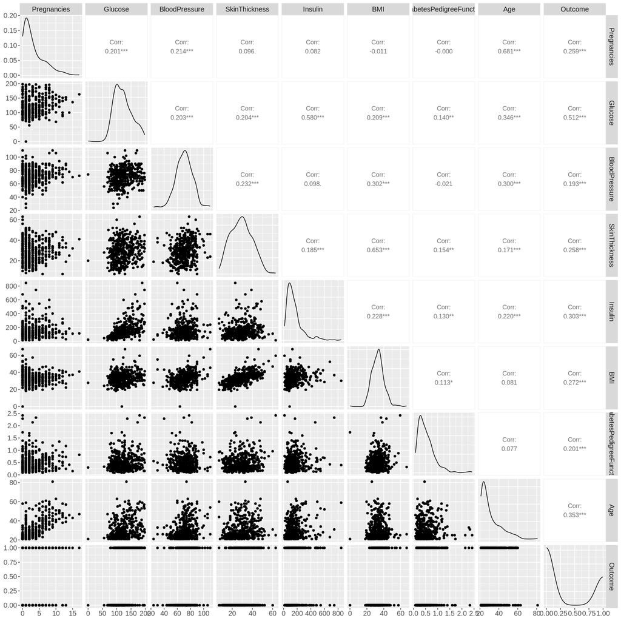

```r
options(repr.plot.width = 15, repr.plot.height = 15)  # Adjust as needed
diabetes_data_pairplots
```

## Correlation Heatmap

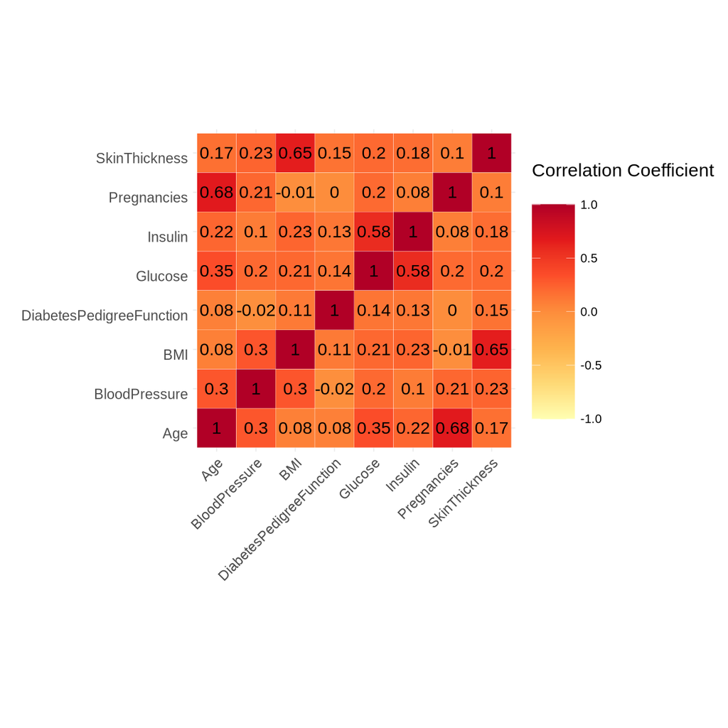

```r
# cor_matrix <- cor(diabetes, use = "complete.obs")

corr_matrix <-
   diabetes %>%
   select(- Outcome) %>%
   cor() %>%
   as_tibble(rownames = 'var1') %>%
   pivot_longer(-var1, names_to = "var2", values_to = "corr")

plot_corr_matrix <-
  corr_matrix %>%
  ggplot(aes(x = var1, y = var2)) +
  geom_tile(aes(fill = corr), color = "white") +
  scale_fill_distiller("Correlation Coefficient \n",
      palette =  "YlOrRd",
      direction = 1,
      limits = c(-1,1)
    ) +
    labs(x = "", y = "") +
    theme_minimal() +
    theme(
        axis.text.x = element_text(angle = 45, vjust = 1, size = 14, hjust = 1),
        axis.text.y = element_text(vjust = 1, size = 14, hjust = 1),
        legend.title = element_text(size = 18),
        legend.text = element_text(size = 12),
        legend.key.size = unit(1.5, "cm")
    ) +
    coord_fixed() +
  geom_text(aes(var1, var2, label = round(corr, 2)), color = "black", size = 6)
options(repr.plot.width = 10, repr.plot.height = 10)  # Adjust as needed
plot_corr_matrix
```

From these pair plots we can see that Insulin and Gluscose levels have a strong positive relationship. Other predictors that stand out are the BMI and Skin thickness plots which also show a strong positive relationship. BMI and Blood pressure also seem to have a slight positive correlation with each other.

These are the predictors we will focus on for this analysis.

## Splitting Data into Training and Testing Datasets

```r
diabetes_split <- initial_split(diabetes, prop = 0.7, strata = Outcome)
training_diabetes <- training(diabetes_split)
testing_diabetes <- testing(diabetes_split)
```

## Visualizations

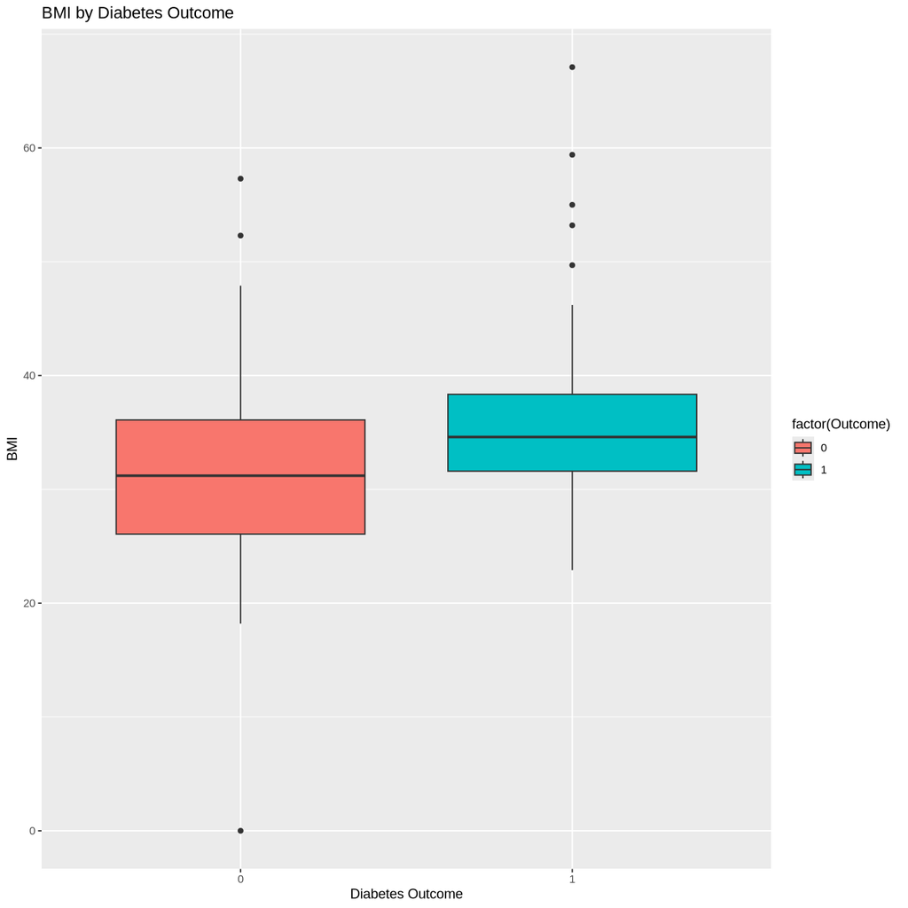

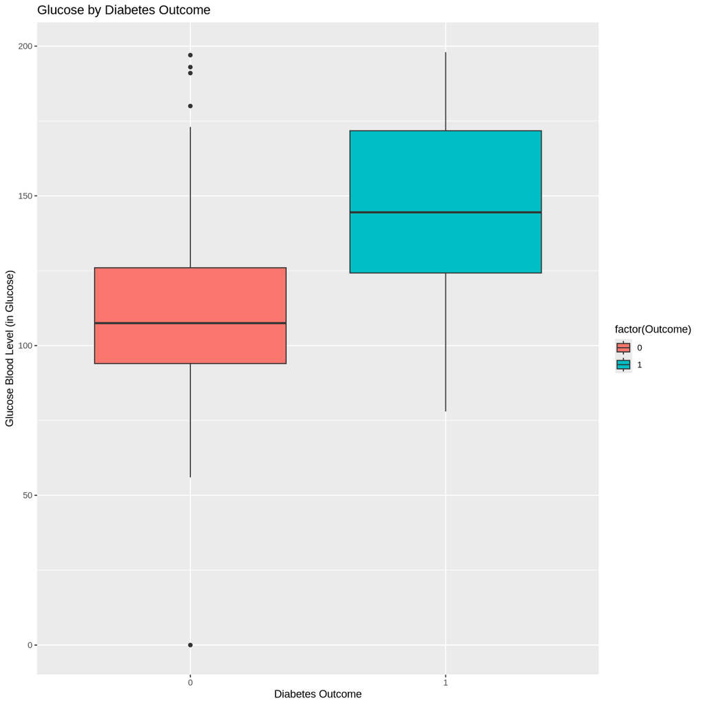

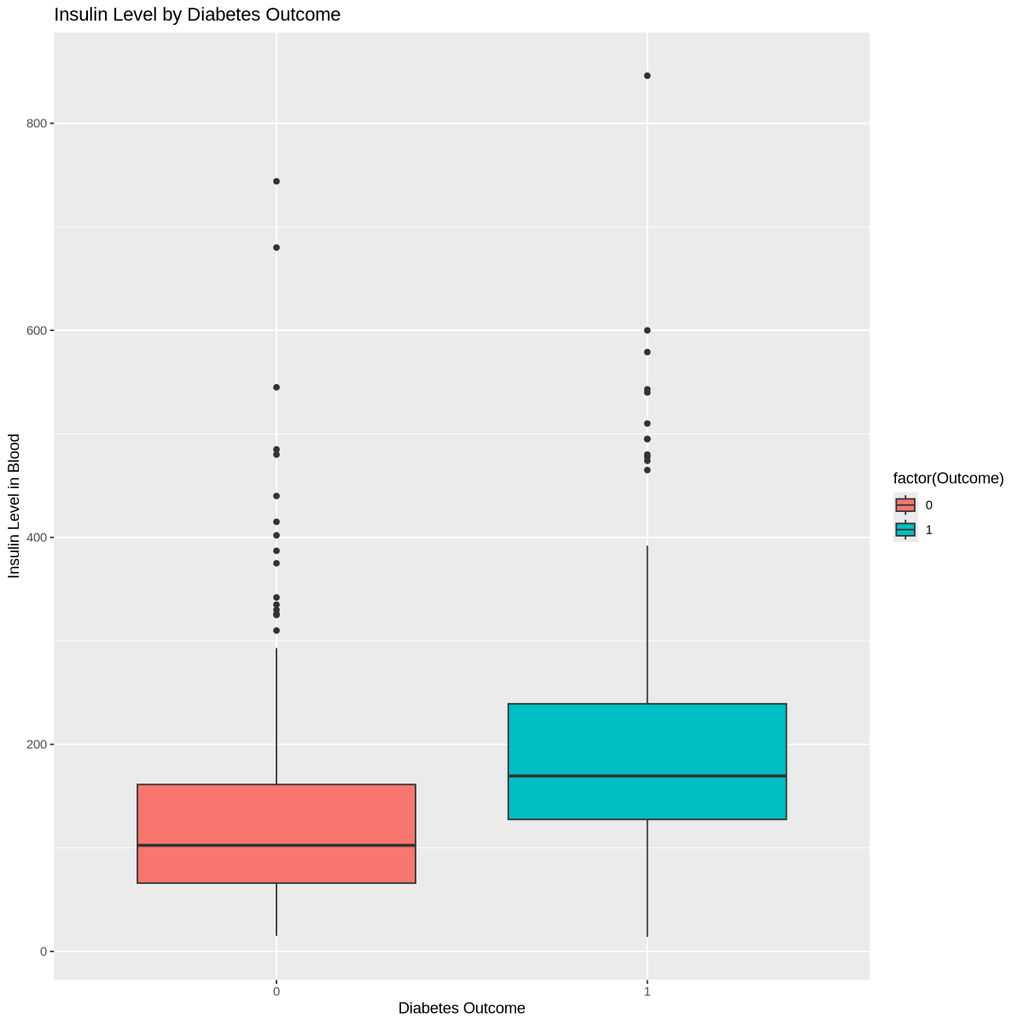

```r
ggplot(diabetes, aes(x = factor(Outcome), y = BMI, fill = factor(Outcome))) +
  geom_boxplot() +
  labs(title = "BMI by Diabetes Outcome", x = "Diabetes Outcome", y = "BMI")

ggplot(diabetes, aes(x = factor(Outcome), y = Glucose, fill = factor(Outcome))) +
  geom_boxplot() +
  labs(title = "Glucose by Diabetes Outcome", x = "Diabetes Outcome", y = "Glucose Blood Level (in Glucose)")

ggplot(diabetes, aes(x = factor(Outcome), y = Insulin, fill = factor(Outcome))) +
  geom_boxplot() +
  labs(title = "Insulin Level by Diabetes Outcome", x = "Diabetes Outcome", y = "Insulin Level in Blood")
```

Looking at the BMI and Glucose boxplots, we notice that patients with diabetes have a higher median BMI, Glucose, and Insulin level in their blood. These are key indicators for diabetes diagnosis.

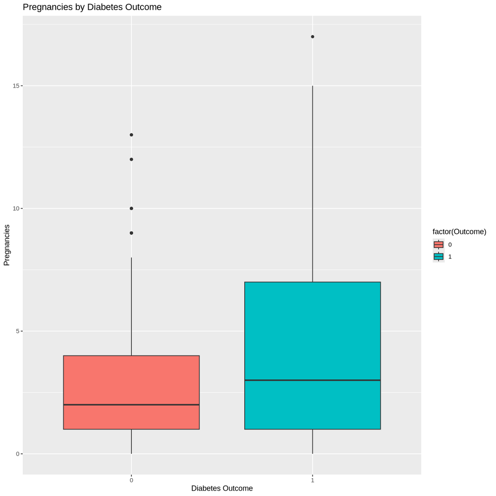

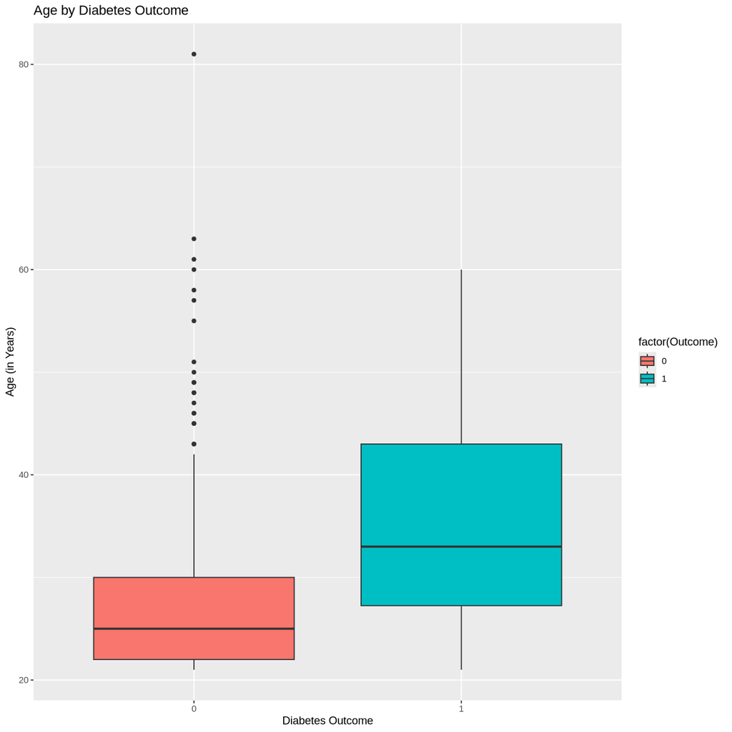

```r
# Do visualization for Pregnancies and Age
ggplot(diabetes, aes(x = factor(Outcome), y = Pregnancies, fill = factor(Outcome))) +
  geom_boxplot() +
  labs(title = "Pregnancies by Diabetes Outcome", x = "Diabetes Outcome", y = "Pregnancies")

ggplot(diabetes, aes(x = factor(Outcome), y = Age, fill = factor(Outcome))) +
  geom_boxplot() +
  labs(title = "Age by Diabetes Outcome", x = "Diabetes Outcome", y = "Age (in Years)")
```

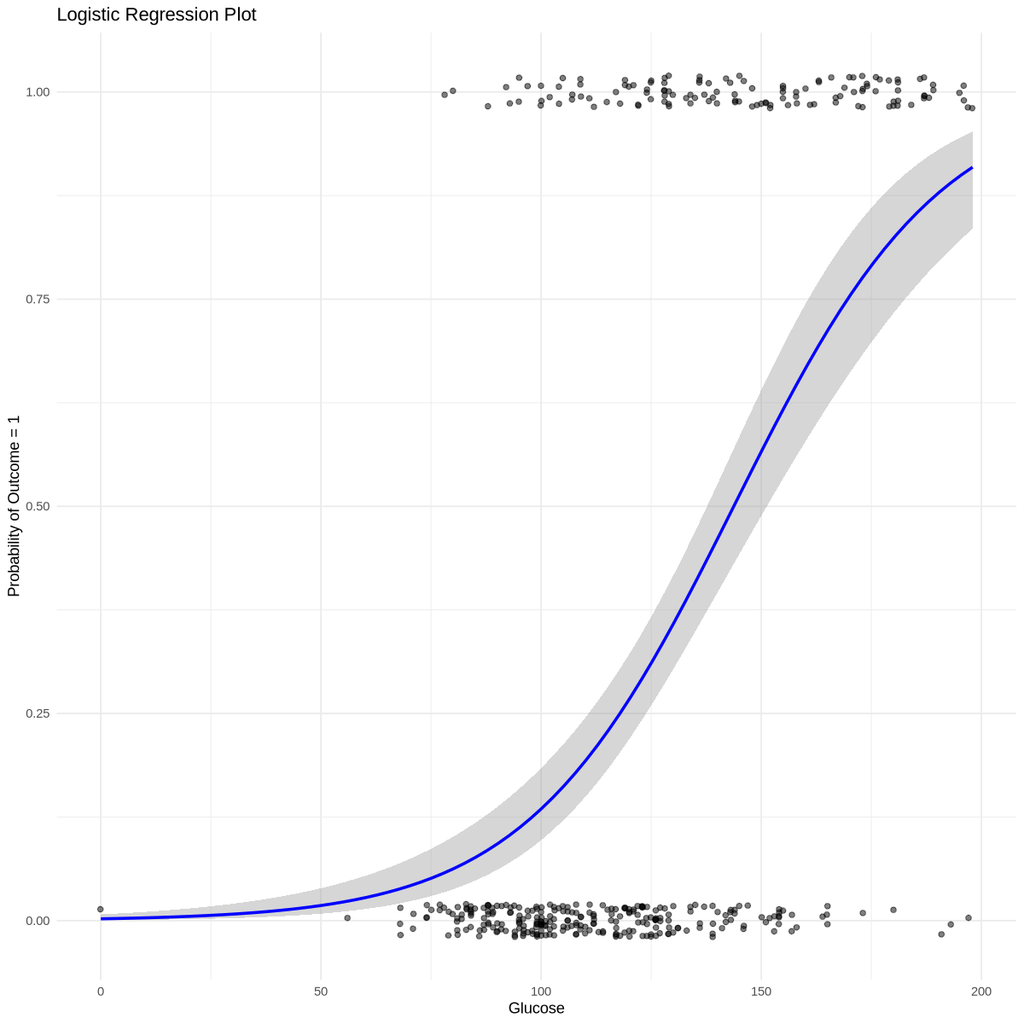

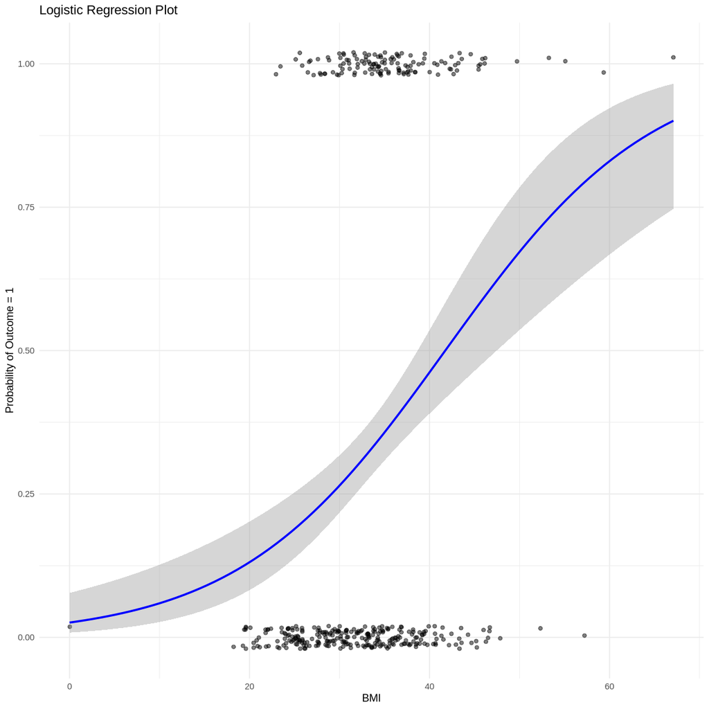

```r
model <- glm(Outcome ~ Glucose, data = diabetes, family = "binomial")

BMI_Glucose_regression_plot = ggplot(diabetes, aes(x = Glucose, y = Outcome)) +
  geom_jitter(width = 0.1, height = 0.02, alpha = 0.5) +  # Scatterplot with slight jitter
  stat_smooth(method = "glm", method.args = list(family = "binomial"), se = TRUE, color = "blue") +
  labs(title = "Logistic Regression Plot", x = "Glucose", y = "Probability of Outcome = 1") +
  theme_minimal()

BMI_BMI_regression_plot = ggplot(diabetes, aes(x = BMI, y = Outcome)) +
  geom_jitter(width = 0.1, height = 0.02, alpha = 0.5) +  # Scatterplot with slight jitter
  stat_smooth(method = "glm", method.args = list(family = "binomial"), se = TRUE, color = "blue") +
  labs(title = "Logistic Regression Plot", x = "BMI", y = "Probability of Outcome = 1") +
  theme_minimal()


BMI_Glucose_regression_plot
BMI_BMI_regression_plot
```

## Log Odds

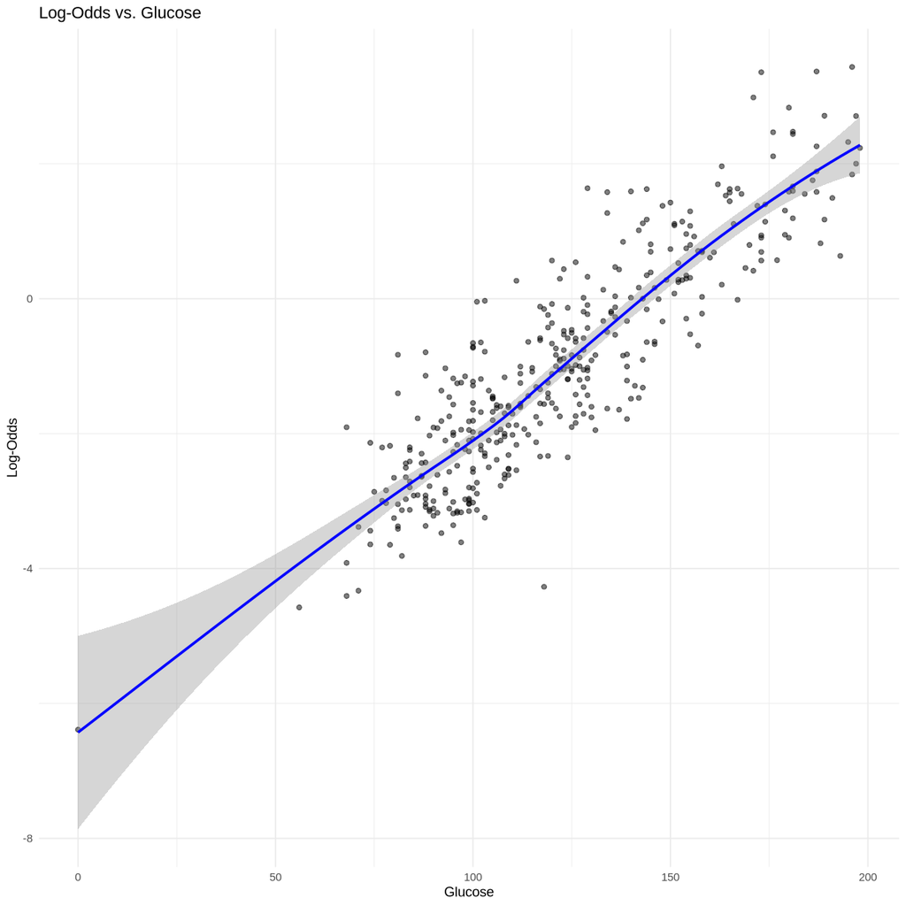

```r
model <- glm(Outcome ~ Glucose + BMI + Age, data = diabetes, family = "binomial")
diabetes$logit <- predict(model, type = "link")  # Get the linear predictor (log-odds)

ggplot(diabetes, aes(x = Glucose, y = logit)) +
  geom_point(alpha = 0.5) +  # Add scatterplot points
  geom_smooth(method = "loess", color = "blue") +  # Add a smoother
  labs(title = "Log-Odds vs. Glucose", x = "Glucose", y = "Log-Odds") +
  theme_minimal()
```

# Methods and Plan: Logistic Regression for Diabetes Prediction

Our dependent variable in this case is the `Outcome` of a diabetes diagnosis. Since `Outcome` is binary a logistic regression model is suitable. We've also shown that the predictors we're using have a linear relationship between each other, from the Log Odds of the predictors. Therefore we can use these predictoors to fit a logistic regression model.

## Proposed Method

For this analysis, I propose using a *logistic regression model* to predict the likelihood of a patient having diabetes based on the given diagnostic predictors. Logistic regression is well-suited for binary outcome variables, such as the presence or absence of diabetes (Outcome = 1 or 0), making it a natural choice for this dataset.

## Why This Method is Appropriate

1. *Nature of the Dependent Variable*:
   - The outcome variable is binary, requiring a method like logistic regression to estimate the probability of a particular class (diabetes diagnosis).
2. *Interpretability*:
   - Logistic regression provides interpretable coefficients that quantify the relationship between predictors (e.g., glucose levels, BMI) and the log-odds of diabetes.
3. *Simplicity*:
   - This model assumes a linear relationship between the predictors and the log-odds, aligning well with exploratory findings (e.g., strong positive correlations observed between glucose, BMI, and diabetes outcomes).
4. *Diagnostic Insights*:
   - Beyond prediction, logistic regression identifies significant predictors and their impact, enhancing our understanding of key risk factors for diabetes.

## Assumptions

To apply logistic regression, the following assumptions are made:

1. *Linearity in Log-Odds*:
   - The predictors have a linear relationship with the log-odds of the dependent variable.
   - This assumption is supported by exploratory analyses and log-odds visualizations in the dataset.
2. *Independence of Observations*:
   - Each patient’s data is assumed to be independent, which is reasonable given the dataset description.
3. *Absence of Multicollinearity*:
   - Predictors should not be highly correlated. Pair plots and the correlation heatmap will guide the selection of predictors to address potential multicollinearity issues.

## Potential Limitations

1. *Linearity Assumption*:
   - If the relationship between predictors and log-odds is non-linear, the model may perform poorly. Polynomial terms or transformations might be required to improve accuracy.
2. *Influence of Outliers*:
   - Outliers in predictors such as glucose or BMI can distort results. Proper diagnostics and data cleaning (e.g., excluding unrealistic values) are critical.
3. *Overfitting Risk*:
   - Including too many predictors relative to the sample size could lead to overfitting. Regularization techniques like LASSO could mitigate this issue.
4. *Bias in Dataset*:
   - The dataset only includes Pima Indian females aged 21 and above, potentially limiting the model’s generalizability to other populations.

## Plan for Implementation

1. *Data Preprocessing*:
   - Clean and normalize predictors.
   - Address missing values and potential outliers.
2. *Feature Selection*:
   - Retain key predictors (e.g., glucose, BMI, age) based on correlation analysis and their significance in prior studies.
3. *Model Building*:
   - Fit a logistic regression model using training data.
   - Use cross-validation to tune the model and assess performance.
4. *Evaluation*:
   - Evaluate the model using metrics like accuracy, precision, recall, and the AUC of the ROC curve.

By leveraging logistic regression, this method balances interpretability and predictive power while addressing the core research question effectively.

# Implementation of a Proposed Model

```r
# Implementation of a Proposed Model

# Load the dataset
data <- diabetes

# Data preprocessing: Remove rows with missing or zero values in SkinThickness and Insulin
data <- data[data$SkinThickness != 0 & data$Insulin != 0, ]

# Split data into training and testing sets
set.seed(42)
train_index <- createDataPartition(data$Outcome, p = 0.7, list = FALSE)
train_data <- data[train_index, ]
test_data <- data[-train_index, ]

# Fit logistic regression model
model <- glm(Outcome ~ ., data = train_data, family = binomial)

# Predict probabilities and outcomes on the test data
test_data$pred_prob <- predict(model, newdata = test_data, type = "response")
test_data$pred_class <- ifelse(test_data$pred_prob > 0.5, 1, 0)

# Evaluate the model
conf_matrix <- table(Predicted = test_data$pred_class, Actual = test_data$Outcome)
auc <- roc(test_data$Outcome, test_data$pred_prob)

# Plot the ROC curve
roc_plot <- ggroc(auc) +
  ggtitle("ROC Curve for Diabetes Prediction") +
  xlab("False Positive Rate") +
  ylab("True Positive Rate") +
  geom_abline(linetype = "dashed") +
  theme_minimal()
print(roc_plot)

# Print confusion matrix and AUC
print("Confusion Matrix:")
print(conf_matrix)
cat("\nAUC Score:", auc$auc, "\n")
```

[output not shown]

[output not shown]